# Quiz 9 R Markdown

Bella Colpo

5/25/2018

# **Introduction**

The following plots visualize raw data that has been downloaded from Washington Department of Ecology. I was interested in picking three sites: Elliot Bay, Port Townsend, and Puget Sound Basin to examine the water quality. I selected particular data using R functions such as filter() and select () and used packages such as ggplot to visualize the data.

# **Plot 1: pH and Depth**

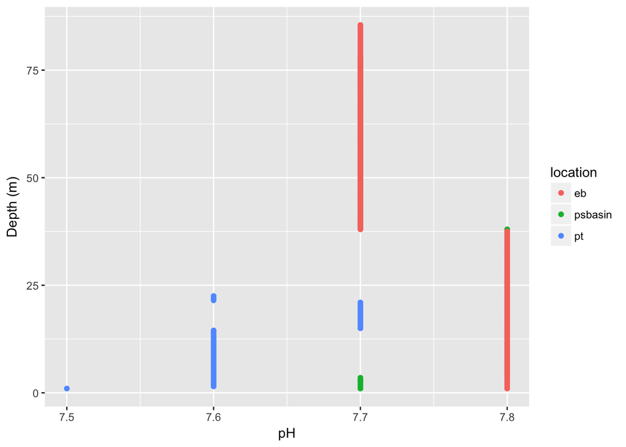

The first plot I created represents the data from [Washington State Department of Ecology Water Quality Data](https://fortress.wa.gov/ecy/eap/marinewq/mwdataset.asp?theyear=2014&themonth=&ec=no&scrolly=21&htmlcsvpref=csv&estuarycode=1&staID=121). Using this dataset from the Washington Department of Ecology, I wanted to see how water quality during the summer of 2016. This was at the tail-end of a few summers of harmful algal bloom outbreaks, so I want to see how water quality was different in a few areas of the Puget Sound. I did not separate the locations in the same graph here, but will do so in the next plot.

# **Plot 2: pH and Depth with facet_wrap[^1]**

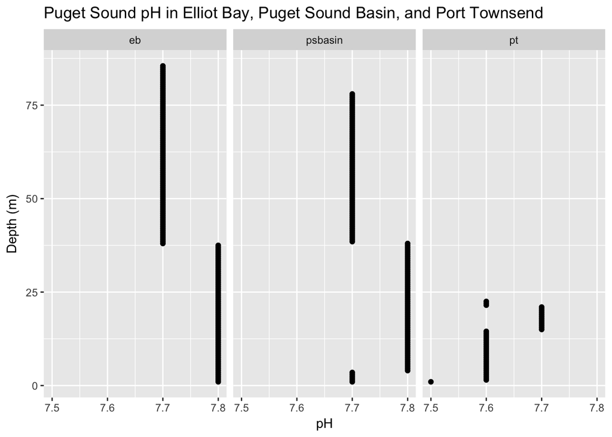

This plot above represents the same data that I isolated from the 2016 for the three locations: Elliot Bay, Puget Sound Basin, and Port Townsend. The plot above, however, uses facet_wrap to separate the three locations in visualization.

# **Plot 3: Improved Plots with Reversed X and Y Axis**

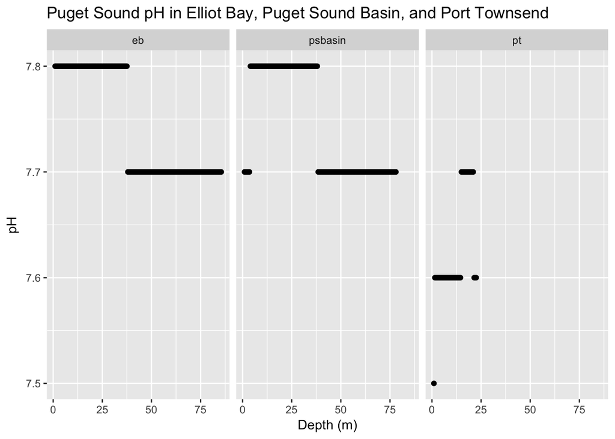

This plot above shows the x and y axis switched from the previous two, representin the pH and depth of the three sites that were surveyed.

# **Plot 4: Averages of Each Location**

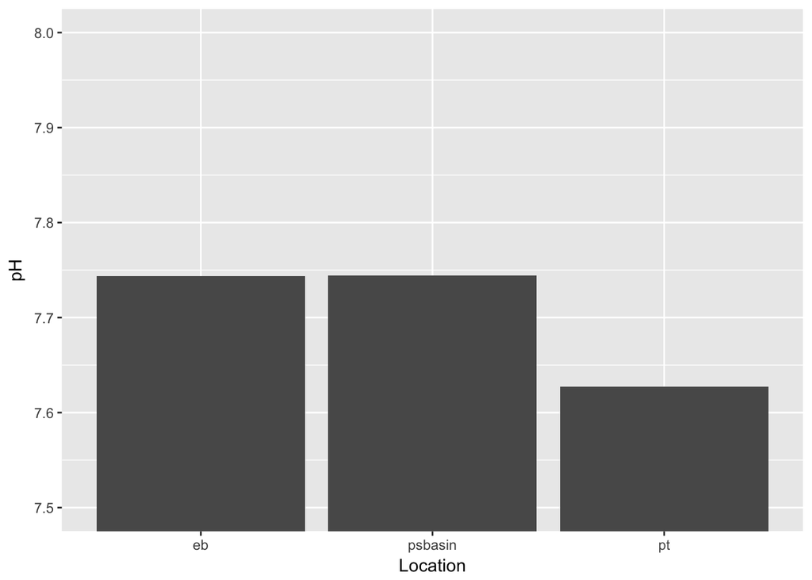

[^1] facet_wrap is a function in R that is embedded into the ggplot that allows you to tier a variable within the dataset. For example, in my code, I used facet_wrap(location) to filter by the location of the surveys within the water quality data that I used.